# Project: Investigate a Dataset - No-Show Appointment

## Table of content

1. Introduction
2. Data Wrangling
3. Exploratory Data Analysis
4. Conclusions

# Introduction

## Dataset Description

This is a dataset of informations about Hospital patients in Brazil which different disease contions and from different regions. This is dataset of information from around 100k medical appointments in Brazil Hospital and is focused on the question of whether or not patients show up for their appointment. The data has variables that determines the possiblity of the patient showing up. More information you can find it here [kaggle](https://www.kaggle.com/datasets/joniarroba/noshowappointments)

## Question(s) for Analysis

1. Which type of disease is mostly associated with the patients?
2. What is the relationship of gender to the type of disease?
3. What is the distribution of age aganist the other variables?
4. What is the possibility of a patient having schoolarship?

```python
#Running all packages that will be used in this dataset

import pandas as pd
import numpy as np
import matplotlib.pyplot as plt
%matplotlib inline
import seaborn as sns
```

# Wrangling

## Assessing the Data

Assessing the dataset to answer the following questions:

- The number of samples in the dataset
- Number of duplicates rows in the dataset
- The datatype of each columns
- Number of missing values if present
- Number of non-null unique values for features in the dataset

```python
#Reading the csv file using pandas function

dataframe =pd.read_csv('noshowappointments-kagglev2-may-2016.csv')

#Printing the whole dataframe
dataframe
```

|  | PatientId | AppointmentID | Gender | ScheduledDay | AppointmentDay | Age | Neighbourhood | Scholarship | Hipertension | Diabetes | Alcoholism | Handcap | SMS_received | No-show |
| --- | --- | --- | --- | --- | --- | --- | --- | --- | --- | --- | --- | --- | --- | --- |
| 0 | 2.987250e+13 | 5642903 | F | 2016-04-29T18:38:08Z | 2016-04-29T00:00:00Z | 62 | JARDIM DA PENHA | 0 | 1 | 0 | 0 | 0 | 0 | No |
| 1 | 5.589978e+14 | 5642503 | M | 2016-04-29T16:08:27Z | 2016-04-29T00:00:00Z | 56 | JARDIM DA PENHA | 0 | 0 | 0 | 0 | 0 | 0 | No |
| 2 | 4.262962e+12 | 5642549 | F | 2016-04-29T16:19:04Z | 2016-04-29T00:00:00Z | 62 | MATA DA PRAIA | 0 | 0 | 0 | 0 | 0 | 0 | No |
| 3 | 8.679512e+11 | 5642828 | F | 2016-04-29T17:29:31Z | 2016-04-29T00:00:00Z | 8 | PONTAL DE CAMBURI | 0 | 0 | 0 | 0 | 0 | 0 | No |
| 4 | 8.841186e+12 | 5642494 | F | 2016-04-29T16:07:23Z | 2016-04-29T00:00:00Z | 56 | JARDIM DA PENHA | 0 | 1 | 1 | 0 | 0 | 0 | No |
| ... | ... | ... | ... | ... | ... | ... | ... | ... | ... | ... | ... | ... | ... | ... |
| 110522 | 2.572134e+12 | 5651768 | F | 2016-05-03T09:15:35Z | 2016-06-07T00:00:00Z | 56 | MARIA ORTIZ | 0 | 0 | 0 | 0 | 0 | 1 | No |
| 110523 | 3.596266e+12 | 5650093 | F | 2016-05-03T07:27:33Z | 2016-06-07T00:00:00Z | 51 | MARIA ORTIZ | 0 | 0 | 0 | 0 | 0 | 1 | No |
| 110524 | 1.557663e+13 | 5630692 | F | 2016-04-27T16:03:52Z | 2016-06-07T00:00:00Z | 21 | MARIA ORTIZ | 0 | 0 | 0 | 0 | 0 | 1 | No |
| 110525 | 9.213493e+13 | 5630323 | F | 2016-04-27T15:09:23Z | 2016-06-07T00:00:00Z | 38 | MARIA ORTIZ | 0 | 0 | 0 | 0 | 0 | 1 | No |
| 110526 | 3.775115e+14 | 5629448 | F | 2016-04-27T13:30:56Z | 2016-06-07T00:00:00Z | 54 | MARIA ORTIZ | 0 | 0 | 0 | 0 | 0 | 1 | No |

110527 rows × 14 columns

```python
#Printing the first rows of the dataframe

dataframe.head()
```

|  | PatientId | AppointmentID | Gender | ScheduledDay | AppointmentDay | Age | Neighbourhood | Scholarship | Hipertension | Diabetes | Alcoholism | Handcap | SMS_received | No-show |
| --- | --- | --- | --- | --- | --- | --- | --- | --- | --- | --- | --- | --- | --- | --- |
| 0 | 2.987250e+13 | 5642903 | F | 2016-04-29T18:38:08Z | 2016-04-29T00:00:00Z | 62 | JARDIM DA PENHA | 0 | 1 | 0 | 0 | 0 | 0 | No |
| 1 | 5.589978e+14 | 5642503 | M | 2016-04-29T16:08:27Z | 2016-04-29T00:00:00Z | 56 | JARDIM DA PENHA | 0 | 0 | 0 | 0 | 0 | 0 | No |
| 2 | 4.262962e+12 | 5642549 | F | 2016-04-29T16:19:04Z | 2016-04-29T00:00:00Z | 62 | MATA DA PRAIA | 0 | 0 | 0 | 0 | 0 | 0 | No |
| 3 | 8.679512e+11 | 5642828 | F | 2016-04-29T17:29:31Z | 2016-04-29T00:00:00Z | 8 | PONTAL DE CAMBURI | 0 | 0 | 0 | 0 | 0 | 0 | No |
| 4 | 8.841186e+12 | 5642494 | F | 2016-04-29T16:07:23Z | 2016-04-29T00:00:00Z | 56 | JARDIM DA PENHA | 0 | 1 | 1 | 0 | 0 | 0 | No |

```python
# print last five rows in dataset to review data and format
dataframe.tail()
```

|  | PatientId | AppointmentID | Gender | ScheduledDay | AppointmentDay | Age | Neighbourhood | Scholarship | Hipertension | Diabetes | Alcoholism | Handcap | SMS_received | No-show |
| --- | --- | --- | --- | --- | --- | --- | --- | --- | --- | --- | --- | --- | --- | --- |
| 110522 | 2.572134e+12 | 5651768 | F | 2016-05-03T09:15:35Z | 2016-06-07T00:00:00Z | 56 | MARIA ORTIZ | 0 | 0 | 0 | 0 | 0 | 1 | No |
| 110523 | 3.596266e+12 | 5650093 | F | 2016-05-03T07:27:33Z | 2016-06-07T00:00:00Z | 51 | MARIA ORTIZ | 0 | 0 | 0 | 0 | 0 | 1 | No |
| 110524 | 1.557663e+13 | 5630692 | F | 2016-04-27T16:03:52Z | 2016-06-07T00:00:00Z | 21 | MARIA ORTIZ | 0 | 0 | 0 | 0 | 0 | 1 | No |
| 110525 | 9.213493e+13 | 5630323 | F | 2016-04-27T15:09:23Z | 2016-06-07T00:00:00Z | 38 | MARIA ORTIZ | 0 | 0 | 0 | 0 | 0 | 1 | No |
| 110526 | 3.775115e+14 | 5629448 | F | 2016-04-27T13:30:56Z | 2016-06-07T00:00:00Z | 54 | MARIA ORTIZ | 0 | 0 | 0 | 0 | 0 | 1 | No |

```python
#Assessing number of shamples in the dataset (rows and columns)
dataframe.shape
```

```
(110527, 14)
```

There are a total of 110,527 rows and 14 columns in this dataset.

```python
#Assessing the datatypes
dataframe.dtypes
```

```
PatientId         float64
AppointmentID       int64
Gender             object
ScheduledDay       object
AppointmentDay     object
Age                 int64
Neighbourhood      object
Scholarship         int64
Hipertension        int64
Diabetes            int64
Alcoholism          int64
Handcap             int64
SMS_received        int64
No-show            object
dtype: object
```

This dataset has an issue with the datatype of Scheduledday and AppointmentDay which are time frame yet are placed under an object(string). We need to change the data type from object to time frame.

```python
dataframe.describe()
```

|  | PatientId | AppointmentID | Age | Scholarship | Hipertension | Diabetes | Alcoholism | Handcap | SMS_received |
| --- | --- | --- | --- | --- | --- | --- | --- | --- | --- |
| count | 1.105270e+05 | 1.105270e+05 | 110527.000000 | 110527.000000 | 110527.000000 | 110527.000000 | 110527.000000 | 110527.000000 | 110527.000000 |
| mean | 1.474963e+14 | 5.675305e+06 | 37.088874 | 0.098266 | 0.197246 | 0.071865 | 0.030400 | 0.022248 | 0.321026 |
| std | 2.560949e+14 | 7.129575e+04 | 23.110205 | 0.297675 | 0.397921 | 0.258265 | 0.171686 | 0.161543 | 0.466873 |
| min | 3.921784e+04 | 5.030230e+06 | -1.000000 | 0.000000 | 0.000000 | 0.000000 | 0.000000 | 0.000000 | 0.000000 |
| 25% | 4.172614e+12 | 5.640286e+06 | 18.000000 | 0.000000 | 0.000000 | 0.000000 | 0.000000 | 0.000000 | 0.000000 |
| 50% | 3.173184e+13 | 5.680573e+06 | 37.000000 | 0.000000 | 0.000000 | 0.000000 | 0.000000 | 0.000000 | 0.000000 |
| 75% | 9.439172e+13 | 5.725524e+06 | 55.000000 | 0.000000 | 0.000000 | 0.000000 | 0.000000 | 0.000000 | 1.000000 |
| max | 9.999816e+14 | 5.790484e+06 | 115.000000 | 1.000000 | 1.000000 | 1.000000 | 1.000000 | 4.000000 | 1.000000 |

From this output we can see we have an age with negative sign (-1). When need to drop this value since we cannot have negative value of age.

```python
#Checking for duplicates in the dataset
dataframe.duplicated().sum()
```

```
0
```

There are no duplicates in the dataset

```python
#Checking the missing values if present
dataframe.isnull().sum()
```

```
PatientId         0
AppointmentID     0
Gender            0
ScheduledDay      0
AppointmentDay    0
Age               0
Neighbourhood     0
Scholarship       0
Hipertension      0
Diabetes          0
Alcoholism        0
Handcap           0
SMS_received      0
No-show           0
dtype: int64
```

It is clear that there are no missing values in this dataset.

```python
#Number of non-unique value
dataframe.nunique()
```

```
PatientId          62299
AppointmentID     110527
Gender                 2
ScheduledDay      103549
AppointmentDay        27
Age                  104
Neighbourhood         81
Scholarship            2
Hipertension           2
Diabetes               2
Alcoholism             2
Handcap                5
SMS_received           2
No-show                2
dtype: int64
```

Assessing the number of unique value of each dataset and what they represent.

```python
#Unique value of Gender
dataframe.Gender.unique()
```

```
array(['F', 'M'], dtype=object)
```

```python
#unique values of Handcap
dataframe.Handcap.unique()
```

```
array([0, 1, 2, 3, 4], dtype=int64)
```

## Cleaning the Dataset

In this dataset there are some columns which are not being to be used, hence they need to dropped. Other columens need to be renamed for easy computation of the dataset.

```python
#Droping the columns which are not going to be used in the analysis of the data
dataframe.drop(['PatientId', 'AppointmentID' ,'ScheduledDay', 'Neighbourhood', 'AppointmentDay', 'AppointmentDay'], axis=1, inplace=True)
#Confirming if the columns have been dropped
dataframe.head()
```

|  | Gender | Age | Scholarship | Hipertension | Diabetes | Alcoholism | Handcap | SMS_received | No-show |
| --- | --- | --- | --- | --- | --- | --- | --- | --- | --- |
| 0 | F | 62 | 0 | 1 | 0 | 0 | 0 | 0 | No |
| 1 | M | 56 | 0 | 0 | 0 | 0 | 0 | 0 | No |
| 2 | F | 62 | 0 | 0 | 0 | 0 | 0 | 0 | No |
| 3 | F | 8 | 0 | 0 | 0 | 0 | 0 | 0 | No |
| 4 | F | 56 | 0 | 1 | 1 | 0 | 0 | 0 | No |

```python
#Renaming the columns to easy format
dataframe.rename(columns= lambda x: x.lower().replace('-','_'), inplace=True)
dataframe.columns
```

```
Index(['gender', 'age', 'scholarship', 'hipertension', 'diabetes',
       'alcoholism', 'handcap', 'sms_received', 'no_show'],
      dtype='object')
```

```python
#To check the count of age having -1 using query function
dataframe.query('age == -1').sum()
```

```
gender           F
age             -1
scholarship      0
hipertension     0
diabetes         0
alcoholism       0
handcap          0
sms_received     0
no_show         No
dtype: object
```

```python
#To check the rows with the value of age is -1
dataframe.query('age == -1')
```

|  | gender | age | scholarship | hipertension | diabetes | alcoholism | handcap | sms_received | no_show |
| --- | --- | --- | --- | --- | --- | --- | --- | --- | --- |
| 99832 | F | -1 | 0 | 0 | 0 | 0 | 0 | 0 | No |

```python
#To drop the value of -1
dataframe.drop(dataframe.query("age == -1").index, inplace=True)
```

```python
#confirming if the -1 value has been dropped
dataframe.query('age == -1').sum()
```

```
gender          0.0
age             0.0
scholarship     0.0
hipertension    0.0
diabetes        0.0
alcoholism      0.0
handcap         0.0
sms_received    0.0
no_show         0.0
dtype: float64
```

From the outcome it is clear that the negative value of age has been dropped

```python
#Renaming the value of no_show column No, Yes to 0,1 respectively
dataframe['no_show'] =dataframe['no_show'].replace(['0', '1'], ['Yes', 'No'])

#To confirm the changes
dataframe['no_show'].unique()
```

```
array(['No', 'Yes'], dtype=object)
```

```python
#To get the statistical distribution of the cleaned data frame
dataframe.describe()
```

|  | age | scholarship | hipertension | diabetes | alcoholism | handcap | sms_received |
| --- | --- | --- | --- | --- | --- | --- | --- |
| count | 110526.000000 | 110526.000000 | 110526.000000 | 110526.000000 | 110526.000000 | 110526.000000 | 110526.000000 |
| mean | 37.089219 | 0.098266 | 0.197248 | 0.071865 | 0.030400 | 0.022248 | 0.321029 |
| std | 23.110026 | 0.297676 | 0.397923 | 0.258266 | 0.171686 | 0.161543 | 0.466874 |
| min | 0.000000 | 0.000000 | 0.000000 | 0.000000 | 0.000000 | 0.000000 | 0.000000 |
| 25% | 18.000000 | 0.000000 | 0.000000 | 0.000000 | 0.000000 | 0.000000 | 0.000000 |
| 50% | 37.000000 | 0.000000 | 0.000000 | 0.000000 | 0.000000 | 0.000000 | 0.000000 |
| 75% | 55.000000 | 0.000000 | 0.000000 | 0.000000 | 0.000000 | 0.000000 | 1.000000 |
| max | 115.000000 | 1.000000 | 1.000000 | 1.000000 | 1.000000 | 4.000000 | 1.000000 |

# EDA

In this stage we want to analyse the dataset in details using visualization so as to answer questions posting in the begining.

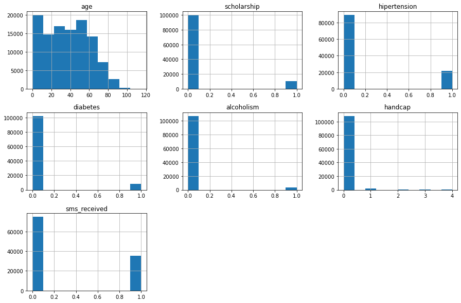

```python
#To get general visualization of the variables bar chart
dataframe.hist(figsize = (15, 10));
```

**Count plot for each and showed up for the appointment**

```python
#To check the number of patients who showed up and those who did not come
dataframe.no_show.value_counts()
```

```
No     88207
Yes    22319
Name: no_show, dtype: int64
```

```python
#Getting the % proportion if no_show
dataframe['no_show'].value_counts() / dataframe.shape[0]*100
```

```
No     79.806561
Yes    20.193439
Name: no_show, dtype: float64
```

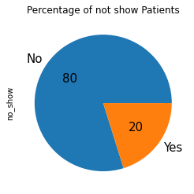

```python
# To plot a pie chart of % of patient who showed up for the appointment
dataframe['no_show'].value_counts().plot(kind='pie', autopct='%.0f', fontsize=15);
plt.title('Percentage of not show Patients')
```

From the finding 80% of the patients will show up for the appointment while 20% will not show up for the appointment. Meaning the probability of a patient showing up for the appointment is 0.8

**Q1. Which type of disease affect most patients**

```python
# To show percentage of patients affected by Hipertension
Hipertension_Proportion =dataframe.hipertension.value_counts()[1] / dataframe.shape[0]*100
Hipertension_Proportion
```

```
19.724770642201836
```

```python
# To show percentage of patients affected by Diabetes
Diabetes_Proportion =dataframe.diabetes.value_counts()[1] / dataframe.shape[0]*100
Diabetes_Proportion
```

```
7.186544342507645
```

```python
# To show percentage of patients affected by Alcoholism
Alcoholism_Proportion =dataframe.alcoholism.value_counts()[1] / dataframe.shape[0]*100
Alcoholism_Proportion
```

```
3.040008685739102
```

```python
# To show percentage of patients affected by Handcap
Handcap_yes =dataframe.handcap.value_counts().sum() - dataframe.handcap.value_counts()[0]
Handcap_Proportion =Handcap_yes / dataframe.shape[0]*100
Handcap_Proportion
```

```
2.0275772216492047
```

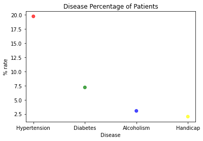

```python
#To plot a bar of Disease Percentage of Patients
colors = ['Red', 'Green', 'Blue', 'Yellow']
locations = [1, 2, 3, 4]
heights = [Hipertension_Proportion, Diabetes_Proportion, Alcoholism_Proportion, Handcap_Proportion]
labels = ['Hypertension', 'Diabetes', 'Alcoholism', 'Handicap']

plt.scatter(locations, heights, color=colors, alpha=0.7);
plt.title('Disease Percentage of Patients')
plt.xlabel('Disease')
plt.ylabel('% rate')
plt.xticks(locations, labels);
```

**Q2. What is the relationship of gender to the type of disease?**

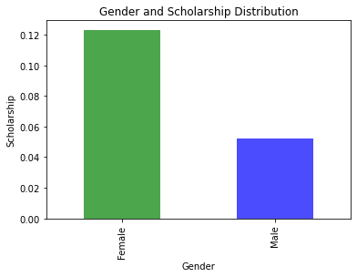

```python
# To show  bar chart Gender and Scholarship Distribution
dataframe.groupby('gender').scholarship.mean().plot(alpha=0.7, color = ['Green', 'Blue'], kind='bar')

# title and labels
plt.xticks([0,1], ['Female', 'Male'])
plt.title('Gender and Scholarship Distribution')
plt.xlabel('Gender')
plt.ylabel('Scholarship')
```

There are more females with the schoolarship compared to males

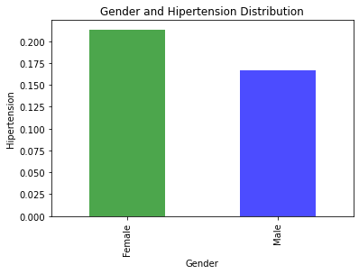

```python
# To show  bar chart Gender and Hipertension Distribution
dataframe.groupby('gender').hipertension.mean().plot(alpha=0.7, color = ['Green', 'Blue'], kind='bar')

# title and labels
plt.xticks([0,1], ['Female', 'Male'])
plt.title('Gender and Hipertension Distribution')
plt.xlabel('Gender')
plt.ylabel('Hipertension')
```

We have more females who are suffering from hipertension compared to male with a small margin

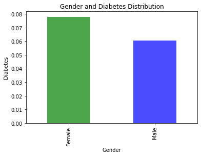

```python
# To show  bar chart Gender and Diabetes Distribution
dataframe.groupby('gender').diabetes.mean().plot(alpha=0.7, color = ['Green', 'Blue'], kind='bar')

# title and labels
plt.xticks([0,1], ['Female', 'Male'])
plt.title('Gender and Diabetes Distribution')
plt.xlabel('Gender')
plt.ylabel('Diabetes')
```

We have more females who are suffering from diabetes compared to male with a small margin

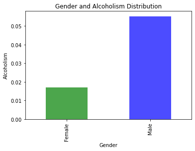

```python
# To show  bar chart Gender and Alcoholism Distribution
dataframe.groupby('gender').alcoholism.mean().plot(alpha=0.7, color = ['Green', 'Blue'], kind='bar')

# title and labels
plt.xticks([0,1], ['Female', 'Male'])
plt.title('Gender and Alcoholism Distribution')
plt.xlabel('Gender')
plt.ylabel('Alcoholism')
```

In this case we have more male patients who are suffering from alcoholism compared to females with higher margin

**Q3. What is the distribution of age aganist the other variables?**

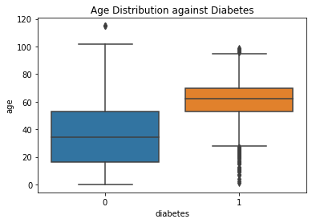

```python
# Using matplotlib function to plot percentile distribution of Age aganist Daibetes
sns.boxplot(x = 'diabetes', y = 'age', data = dataframe)
plt.title("Age Distribution against Diabetes")
plt.show()
```

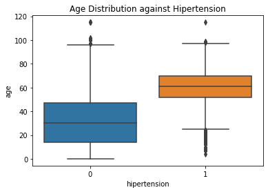

```python
# Using matplotlib function to plot percentile distribution of Age aganist Hipertension
sns.boxplot(x = 'hipertension', y = 'age', data = dataframe)
plt.title("Age Distribution against Hipertension")
plt.show()
```

From the results above we can say that the 50% percentile distribution of age of patients without hipertension range from 15 to 50 years, wheres for the patients who have hiprtension range from 55 to 70 yeras.

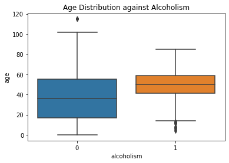

```python
# Using matplotlib function to plot percentile distribution of Age aganist Alcoholism
sns.boxplot(x = 'alcoholism', y = 'age', data = dataframe)
plt.title("Age Distribution against Alcoholism")
plt.show()
```

From the results above we can say that the 50% percentile distribution of age of patients without alcoholism range from 15 to 55 years, wheres for the patients who have alcoholism range from 40 to 60 yeras.

[figure not shown]

```python
# Using matplotlib function to plot percentile distribution of Age aganist Handcap
sns.boxplot(x = 'handcap', y = 'age', data = dataframe)
plt.title("Age Distribution against Diabetes")
plt.show()
```

From the results above we can say that the median 50% percentile distribution of age of patients without handcap is 35 years, wheres for the patients who have 1 handcap is 50 years, 2 handcap is 45 years, 3 handcap is 65 years and 4 handcap is 15 years.

**Q4. What is the possibility of a patient to have a schoolarship?**

```python
# To find the proportion of patients with schoolarship
scholarship_proportion = dataframe.scholarship.value_counts()[1] / dataframe.shape[0]
scholarship_proportion
```

```
0.09826647123753687
```

```python
# To fing the proportion of patients without schoolarship
noscholarship_proportion = dataframe.scholarship.value_counts()[0] / dataframe.shape[0]
noscholarship_proportion
```

```
0.9017335287624632
```

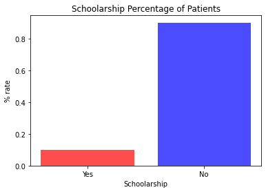

```python
#To plot a bar of Disease Percentage of Patients
colors = ['Red','Blue']
locations = [1, 2,]
heights = [scholarship_proportion, noscholarship_proportion]
labels = ['Yes', 'No']

plt.bar(locations, heights, color=colors, alpha=0.7);
plt.title('Schoolarship Percentage of Patients')
plt.xlabel('Schoolarship')
plt.ylabel('% rate')
plt.xticks(locations, labels);
```

# Conclusions

**Q3. What is the distribution of age aganist the other variables?**

**Q4. What is the possibility of a patient to have a schoolarship?**

From the calculations and bar chart above it is clear that the possibility of a patient having schoolarship is 9.8%

**Limitations**

1. We did not have enough informations about the negative value of age, hence iI was forced to drop the whole row of -1 value of age.
2. This data analysis didn't tackle the effect of variables at the percentage of showing up of patients for their appointment.

```python
from subprocess import call
call(['python', '-m', 'nbconvert', 'Investigate_a_Dataset.ipynb'])
```

```
1
```